RH Exemple

**Exercices 2008 à 2012**

Fabrice Nicol

mar. 18 nov. 2014

# 1. Statistiques de population

### 1.1 Effectifs

*Tableau 1*

|  | 2008 | 2009 | 2010 | 2011 | 2012 |
| --- | --- | --- | --- | --- | --- |
| Total effectifs | 1 119,0 | 1 146,0 | 1 221,0 | 1 215,0 | 1 260,0 |
| dont présents 12 mois | 870,0 | 953,0 | 922,0 | 991,0 | 1 037,0 |
| dont fonctionnaires | 704,0 | 706,0 | 733,0 | 735,0 | 744,0 |
| dont fonct. présents 12 mois | 644,0 | 661,0 | 667,0 | 698,0 | 690,0 |
| dont élus | 100,0 | 72,0 | 75,0 | 73,0 | 76,0 |
| dont élus présents 12 mois | 37,0 | 67,0 | 69,0 | 72,0 | 71,0 |
| dont vacataires détectés (a) | 0,0 | 1,0 | 0,0 | 0,0 | 0,0 |
| dont assistantes maternelles détectées (a) | 0,0 | 0,0 | 0,0 | 0,0 | 0,0 |
| Total ETP/année (b) | 742,8 | 747,6 | 771,0 | 797,6 | 824,4 |
| Total ETPT/année (c) | 703,3 | 709,4 | 714,9 | 740,8 | 759,2 |
| Total ETPT/année personnes en place (d) | 0,0 | 608,6 | 597,1 | 611,5 | 622,3 |
| Total ETPT/année fonctionnaires | 604,3 | 605,5 | 605,1 | 617,6 | 625,1 |
| Total ETPT/année titulaires à temps complet | 457,0 | 479,0 | 470,0 | 463,0 | 478,0 |

**Nota:**  
*(a) Sur la base des libellés d’emploi et des libellés de lignes de paye. La détection peut être lacunaire*  
*(b) ETP : Equivalent temps plein = rémunération . quotité*  
*(c) ETPT : Equivalent temps plein travaillé = ETP . 12/nombre de mois travaillés dans l’année*  
*(d) Personnes en place : présentes en N et N-1 avec la même quotité*  
*Les cinq dernières lignes du tableau sont calculées en ne tenant pas compte des élus.

*Effectifs pourvus mesurés par l’émission d’un bulletin de paie dans l’année.*

Lien vers la base des effectifs

### 1.2 Pyramide des âges, personnels non élus

*Tableau 2*

| Statistique | Âge des personnels au 31/12/2008 | Effectif |
| --- | --- | --- |
| Minimum | 22 |  |
| 1er quartile | 34 |  |
| Médiane | 42 |  |
| Moyenne | 42,65 | 941 |
| 3ème quartile | 52 |  |
| Maximum | 68 |  |

*Tableau 3*

| Statistique | Âge des personnels au 31/12/2012 | Effectif |
| --- | --- | --- |
| Minimum | 18 |  |
| 1er quartile | 31 |  |
| Médiane | 40 |  |
| Moyenne | 40,55 | 1064 |
| 3ème quartile | 49 |  |
| Maximum | 112 |  |

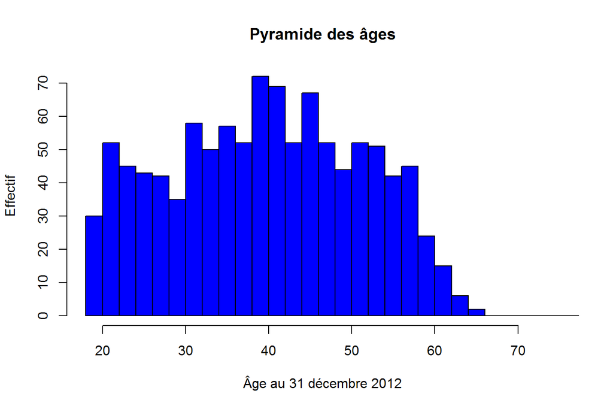

Lien vers la base des âges

### 1.3 Pyramide des âges, personnels fonctionnaires stagiaires et titulaires

*Tableau 4*

| Statistique | Âge des personnels au 31/12/2008 | Effectif |
| --- | --- | --- |
| Minimum | 26 |  |
| 1er quartile | 38 |  |
| Médiane | 45 |  |
| Moyenne | 45,42 | 674 |
| 3ème quartile | 53 |  |
| Maximum | 68 |  |

*Tableau 5*

| Statistique | Âge des personnels au 31/12/2012 | Effectif |
| --- | --- | --- |
| Minimum | 23 |  |
| 1er quartile | 37 |  |
| Médiane | 43 |  |
| Moyenne | 43,78 | 723 |
| 3ème quartile | 51 |  |
| Maximum | 66 |  |

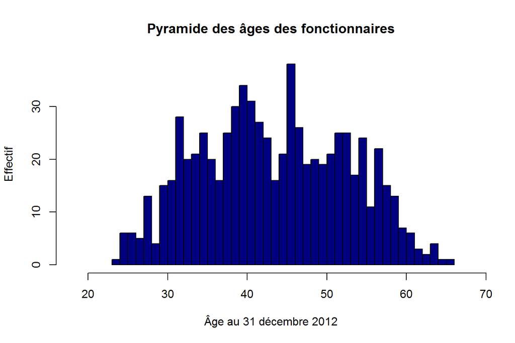

Lien vers la base des âges

### 1.4 Effectifs des personnels par durée de service

**Personnels en fonction des exercices 2008 à 2012 inclus :**

*Tableau 6*

| Plus de 2 ans | Moins de 2 ans | Moins d’un an | Moins de six mois |
| --- | --- | --- | --- |
| 798 | 319 | 211 | 137 |

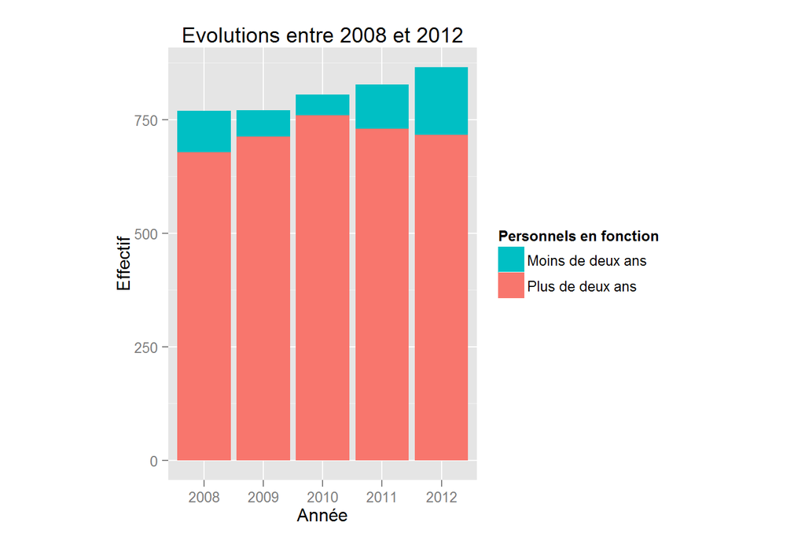

**Effectifs**

*Tableau 7*

|  | 2008 | 2009 | 2010 | 2011 | 2012 |
| --- | --- | --- | --- | --- | --- |
| Plus de deux ans | 678 | 713 | 759 | 730 | 716 |
| Moins de deux ans | 91 | 58 | 46 | 97 | 149 |
| Total | 769 | 771 | 805 | 827 | 865 |

**Nota :** *Personnels en place : ayant servi au moins deux années consécutives pendant la période.*  
*Plus/moins de deux ans : plus/mois de 730 jours sur la période sous revue.*

# 2. Rémunérations brutes : analyse pour l’exercice 2008

## 2.1 Masse salariale brute de l’ensemble des agents

### Cumuls des rémunérations brutes pour l’exercice 2008

*Personnels (hors élus)*

*Tableau 8*

[output not shown]

*Elus*

*Tableau 9*

[output not shown]

**Définitions :**

*Brut annuel (bulletins)* : somme du champ *Brut*  
*Brut annuel (lignes)* : somme du champ *Montant* des lignes de paye, dont :  
*Primes* : indemnités sauf remboursements, certaines IJSS, indemnités d’élu le cas échéant, Supplément familial de traitement et Indemnité de résidence  
*Indemnités d’élu* : toutes rémunérations indemnitaires des élus  
*Autres rémunérations* : acomptes, retenues sur brut, rémunérations diverses, rappels

**Tests de cohérence**

Somme des rémunérations brutes versées aux personnels (non élus) :

*Tableau 10*

[output not shown]

à comparer aux soldes des comptes 641 et 648 du compte de gestion.

Somme des rémunérations brutes versées (élus) :

*Tableau 11*

[output not shown]

Les résultats sont exprimés en euros.

## 2.2 Masse salariale brute des fonctionnaires

*Cette section concerne les personnels fonctionnaires titulaires et stagiaires*

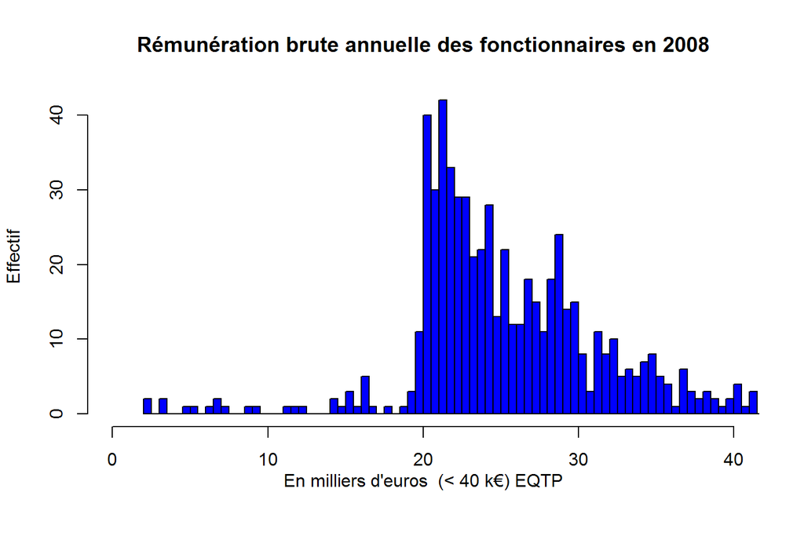

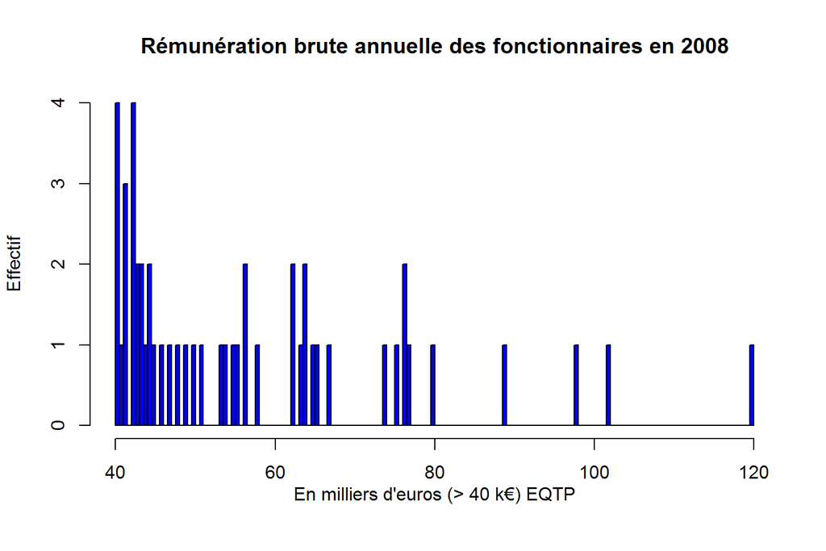

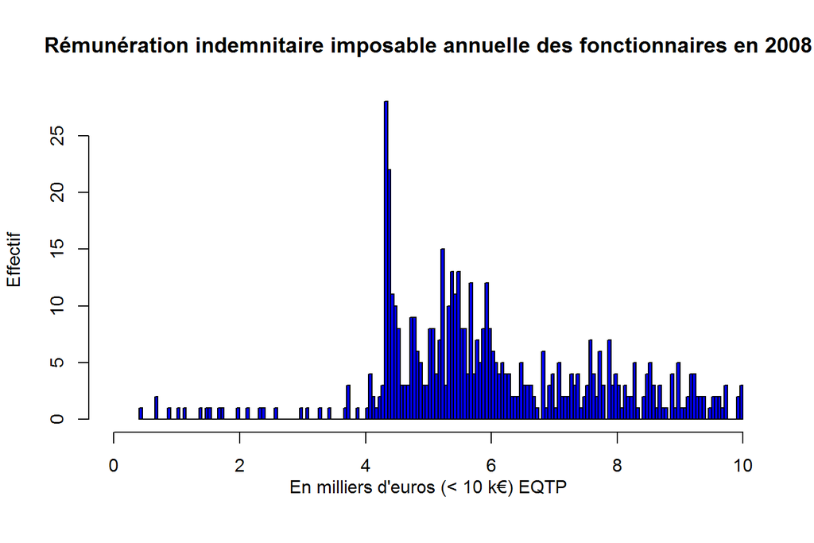

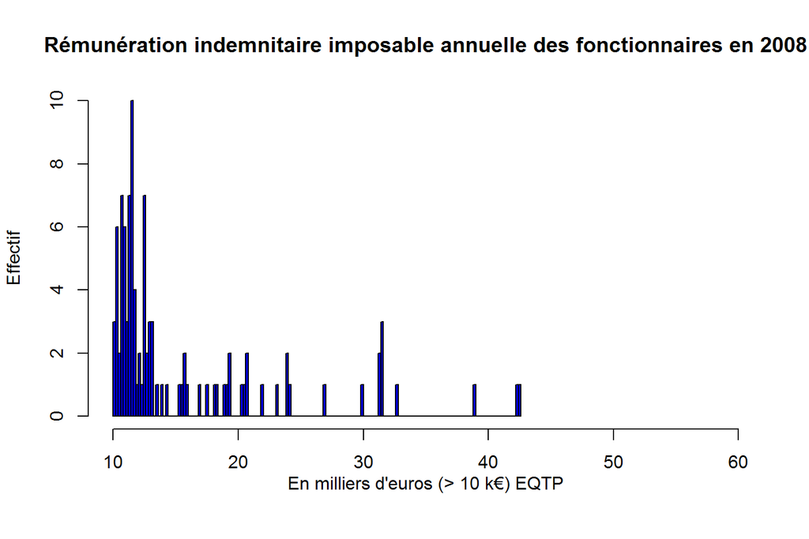

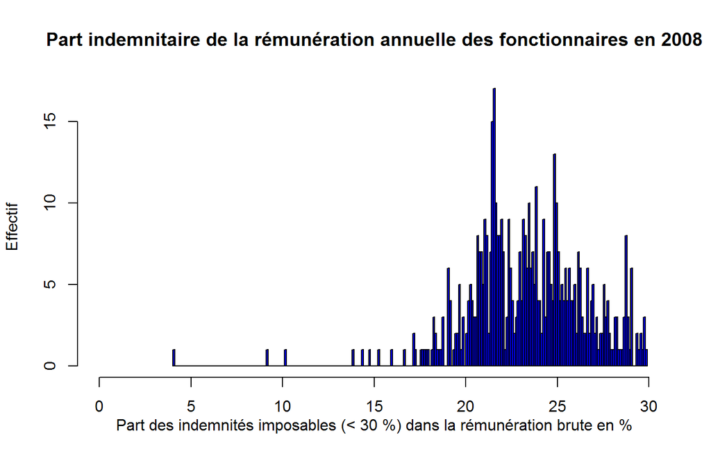

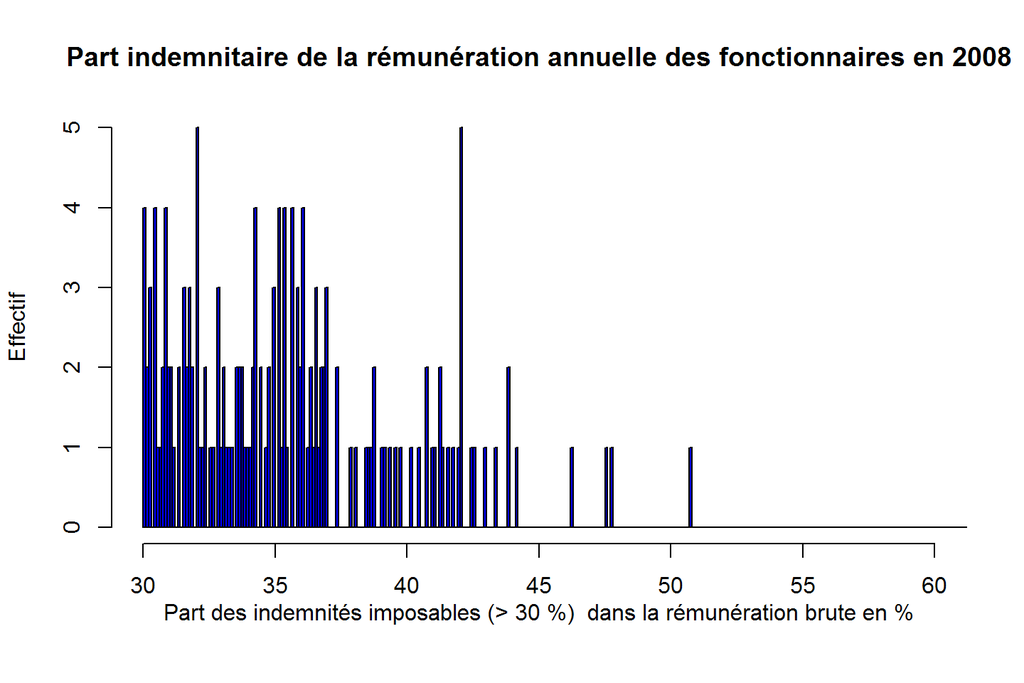

**Nota :**  
*EQTP : Equivalent temps plein = 12 . moyenne du ratio ratio rémunération / quotité*

**Effectif : 693**

**Tests de cohérence**

Somme des rémunérations brutes versées aux personnels titulaires et stagiaires :

*Tableau 12*

[output not shown]

**Définitions :**

*Brut annuel (bulletins)* : somme du champ *Brut*  
*Brut annuel (lignes)* : somme du champ *Montant* des lignes de paye, dont :  
*Primes* : indemnités sauf remboursements, certaines IJSS, indemnités d’élu le cas échéant, Supplément familial de traitement et Indemnité de résidence  
*Indemnités d’élus* : toutes rémunérations indemnitaires des élus  
*Autres rémunérations* : acomptes, retenues sur brut, rémunérations diverses, rappels

**Tests de cohérence**

Somme des rémunérations brutes versées aux personnels (non élus) :

*Tableau 13*

[output not shown]

A comparer aux soldes des comptes 6411, 6419 et 648 du compte de gestion.

**Formation et distribution du salaire brut moyen par tête (SMPT) en EQTP pour l’année 2008**

*Tableau 14*

| Statistique | Traitement indiciaire | Primes | Autres rémunérations | Effectif |
| --- | --- | --- | --- | --- |
| Minimum | 0 | 0 | 0 |  |
| 1er quartile | 16 160 | 4 799 | 0 |  |
| Médiane | 17 808 | 5 917 | 0 |  |
| Moyenne | 19 361 | 7 171 | 0 | 693 |
| 3ème quartile | 22 354 | 8 233 | 0 |  |
| Maximum | 80 378 | 42 553 | 0 |  |

*Tableau 15*

| Statistique | Total lignes hors rappels | Total brut | SMPT brut en EQTP | Part de la rém. indemnitaire | Effectif |
| --- | --- | --- | --- | --- | --- |
| Minimum | 65,96 | 65,96 | 0 | 4,067 |  |
| 1er quartile | 21 349,32 | 21 298,62 | 21 092 | 21,751 |  |
| Médiane | 24 492,19 | 24 333,30 | 24 248 | 24,662 |  |
| Moyenne | 26 608,83 | 26 436,46 | 25 583 | 26,411 | 691 |
| 3ème quartile | 29 374,82 | 29 223,64 | 29 174 | 29,238 |  |
| Maximum | 122 738,87 | 119 918,29 | 119 591 | 100,000 |  |

**Catégorie A**

Pas de statistique en l’absence de fichier des catégories.

**Effectif : 0**

**Catégorie B**

Pas de statistique en l’absence de fichier des catégories.

**Effectif : 0**

**Catégorie C**

Pas de statistique en l’absence de fichier des catégories.

**Effectif : 0**

## 2.3 Contractuels, vacataires et stagiaires inclus

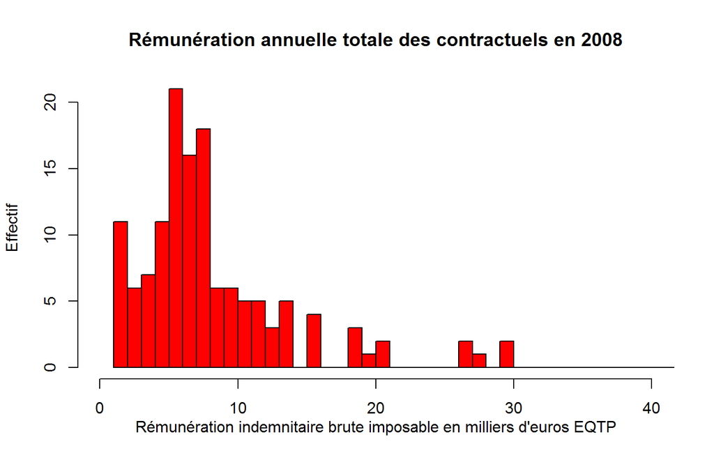

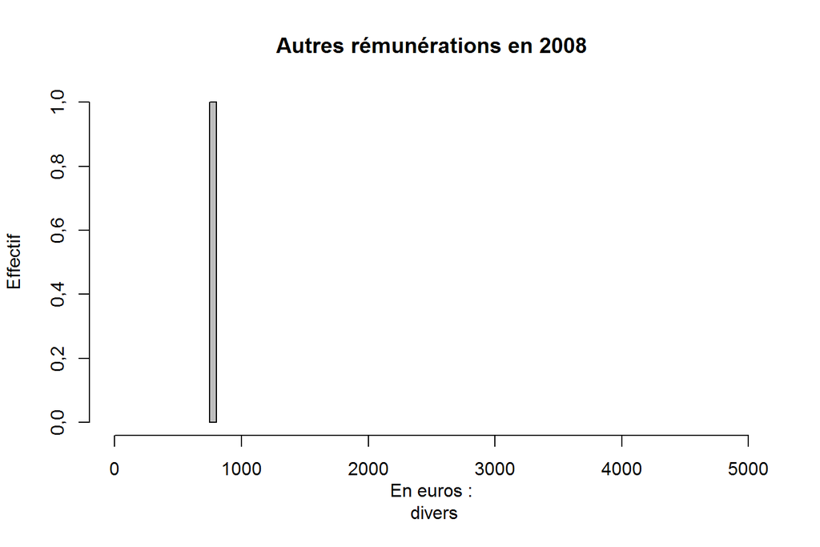

**Formation et distribution du salaire brut moyen par tête (SMPT) en EQTP pour l’année 2008**

*Tableau 16*

| Statistique | Primes | Autres rémunérations | Effectif |
| --- | --- | --- | --- |
| Minimum | 0 | 0,000 |  |
| 1er quartile | 412 | 0,000 |  |
| Médiane | 2 389 | 0,000 |  |
| Moyenne | 4 310 | 2,788 | 286 |
| 3ème quartile | 6 074 | 0,000 |  |
| Maximum | 43 361 | 797,420 |  |

*Tableau 17*

| Statistique | Total rémunérations | Total rémunérations EQTP | Effectif |
| --- | --- | --- | --- |
| Minimum | 0 | 0 |  |
| 1er quartile | 1 615 | 0 |  |
| Médiane | 10 001 | 0 |  |
| Moyenne | 16 002 | 14 156 | 286 |
| 3ème quartile | 24 822 | 26 146 |  |
| Maximum | 97 650 | 97 383 |  |

# 3. Rémunérations brutes : analyse pour l’exercice 2012

## 3.1 Masse salariale brute de l’ensemble des agents

### Cumuls des rémunérations brutes pour l’exercice 2012

*Personnels (hors élus)*

*Tableau 18*

[output not shown]

*Elus*

*Tableau 19*

[output not shown]

**Définitions :**

*Brut annuel (bulletins)* : somme du champ *Brut*  
*Brut annuel (lignes)* : somme du champ *Montant* des lignes de paye, dont :  
*Primes* : indemnités sauf remboursements, certaines IJSS, indemnités d’élu le cas échéant, Supplément familial de traitement et Indemnité de résidence  
*Indemnités d’élu* : toutes rémunérations indemnitaires des élus  
*Autres rémunérations* : acomptes, retenues sur brut, rémunérations diverses, rappels

**Tests de cohérence**

Somme des rémunérations brutes versées aux personnels (non élus) :

*Tableau 20*

[output not shown]

à comparer aux soldes des comptes 641 et 648 du compte de gestion.

Somme des rémunérations brutes versées (élus) :

*Tableau 21*

[output not shown]

Les résultats sont exprimés en euros.

## 3.2 Fonctionnaires titulaires et stagiaires

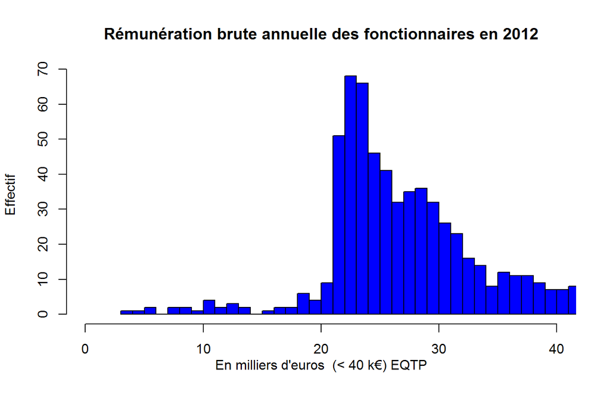

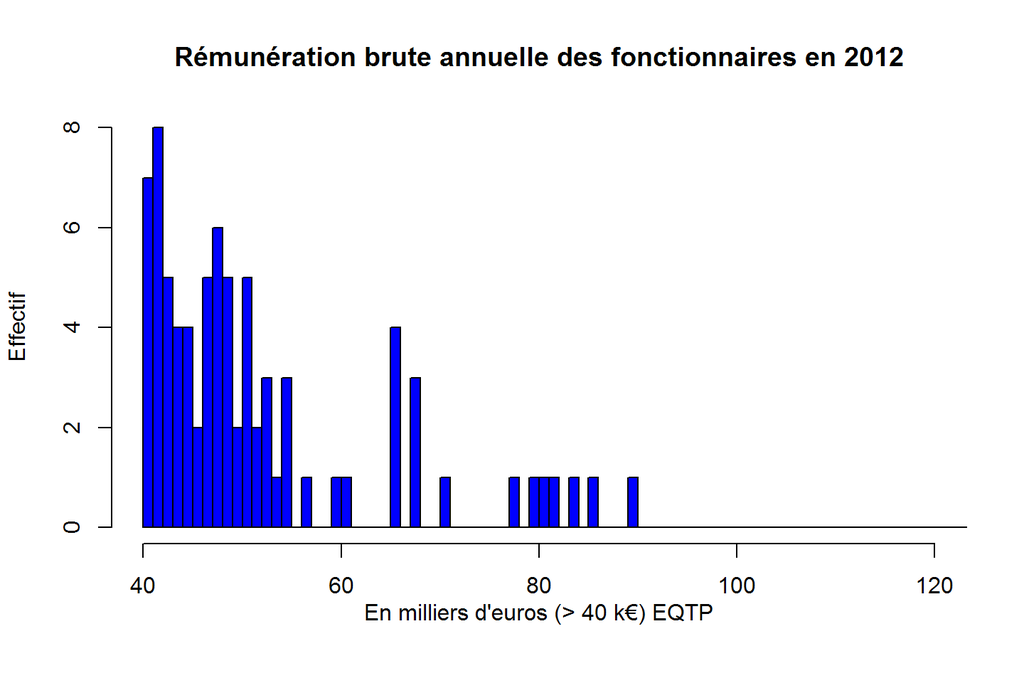

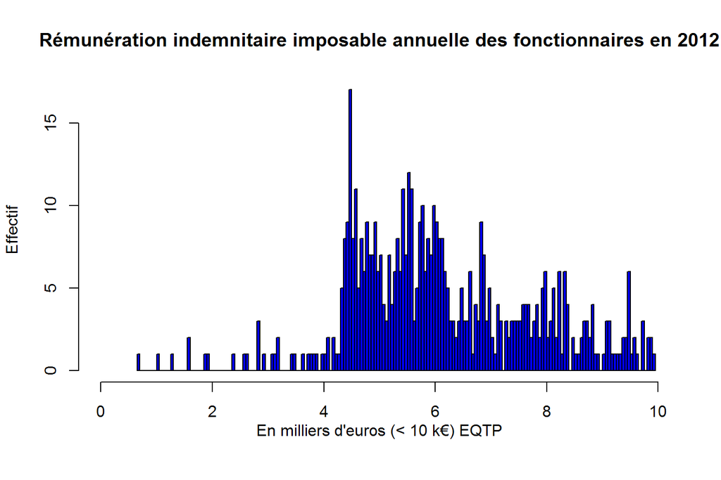

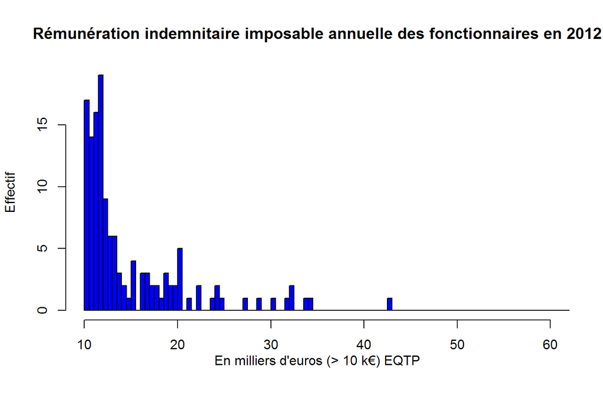

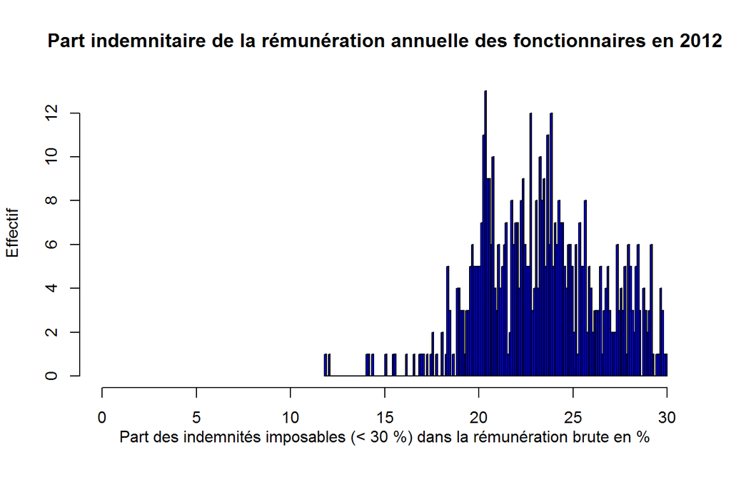

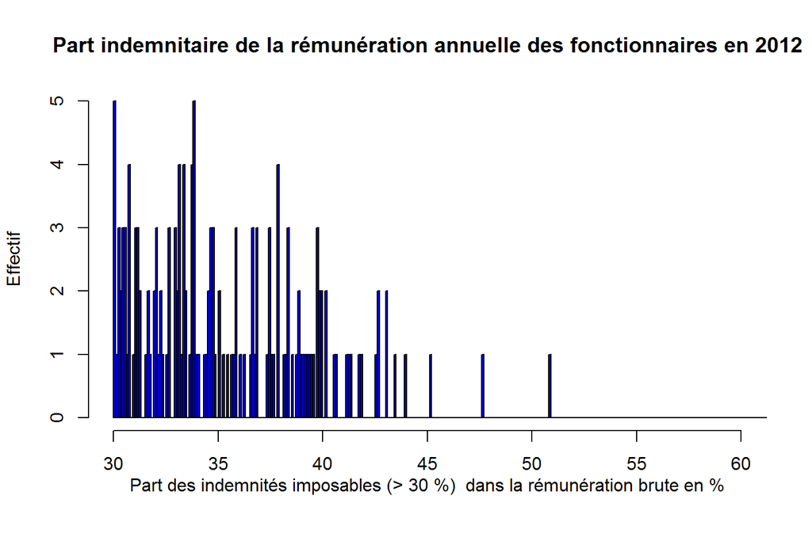

**Nota :**  
*EQTP = Equivalent temps plein = 12 . moyenne du ratio rémunération / quotité*

**Effectif : 739**

**Tests de cohérence**

Somme des rémunérations brutes versées aux personnels titulaires et stagiaires :

*Tableau 22*

[output not shown]

**Définitions :**

*Brut annuel (bulletins)* : somme du champ *Brut*  
*Brut annuel (lignes)* : somme du champ *Montant* des lignes de paye, dont :  
*Primes* : indemnités sauf remboursements, certaines IJSS, indemnités d’élu le cas échéant, Supplément familial de traitement et Indemnité de résidence  
*Indemnités d’élus* : toutes rémunérations indemnitaires des élus  
*Autres rémunérations* : acomptes, retenues sur brut, rémunérations diverses, rappels

**Tests de cohérence**

Somme des rémunérations brutes versées aux personnels (non élus) :

*Tableau 23*

[output not shown]

A comparer aux soldes des comptes 6411, 6419 et 648 du compte de gestion.

**Formation et distribution du salaire brut moyen par tête (SMPT) en EQTP pour l’année 2012**

*Tableau 24*

| Statistique | Traitement indiciaire | Primes | Autres rémunérations | Effectif |
| --- | --- | --- | --- | --- |
| Minimum | 0 | 0 | -329,58 |  |
| 1er quartile | 17 280 | 4 926 | -54,37 |  |
| Médiane | 19 141 | 6 243 | 0,00 |  |
| Moyenne | 20 677 | 7 822 | -22,56 | 739 |
| 3ème quartile | 23 892 | 8 759 | 0,00 |  |
| Maximum | 54 217 | 106 703 | 69,35 |  |

*Tableau 25*

| Statistique | Total lignes hors rappels | Total brut | SMPT brut en EQTP | Part de la rém. indemnitaire | Effectif |
| --- | --- | --- | --- | --- | --- |
| Minimum | 0 | 121,6 | 0 | 0,00 |  |
| 1er quartile | 22 634 | 22 611,4 | 22 388 | 21,64 |  |
| Médiane | 25 937 | 25 942,1 | 25 522 | 24,30 |  |
| Moyenne | 28 574 | 28 457,3 | 27 211 | 26,27 | 737 |
| 3ème quartile | 31 744 | 31 589,3 | 31 345 | 28,96 |  |
| Maximum | 106 703 | 108 054,5 | 330 734 | 100,00 |  |

**Catégorie A**

Pas de statistique en l’absence de fichier des catégories.

**Effectif : 0**

**Catégorie B**

Pas de statistique en l’absence de fichier des catégories.

**Effectif : 0**

**Catégorie C**

Pas de statistique en l’absence de fichier des catégories.

**Effectif : 0**

## 3.3 Contractuels, vacataires et stagiaires inclus

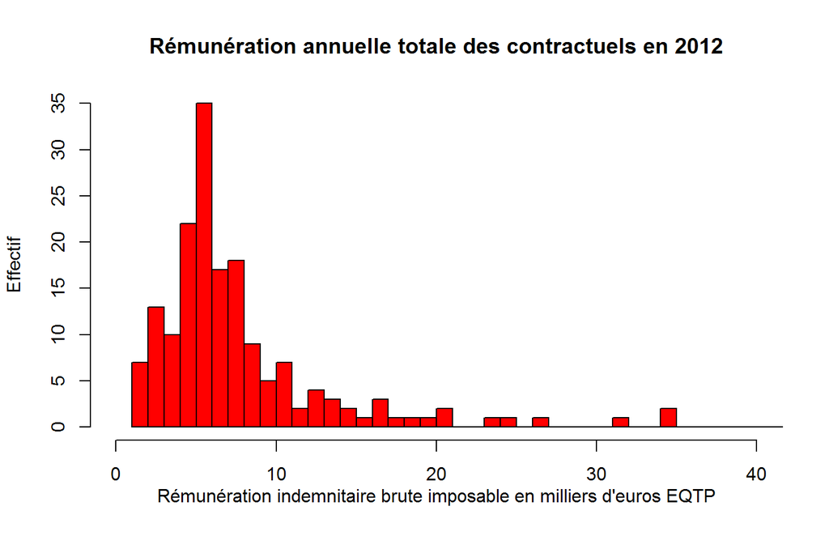

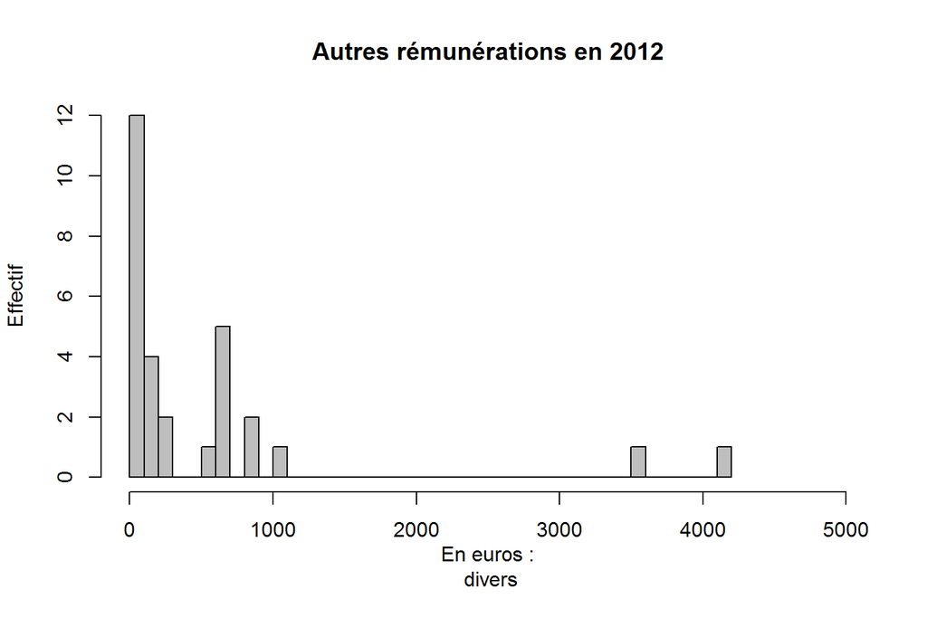

*Tableau 26*

| Statistique | Primes | Autres rémunérations | Effectif |
| --- | --- | --- | --- |
| Minimum | 0 | -162,93 |  |
| 1er quartile | 0 | 0,00 |  |
| Médiane | 2 741 | 0,00 |  |
| Moyenne | 4 364 | 32,73 | 400 |
| 3ème quartile | 6 449 | 0,00 |  |
| Maximum | 60 095 | 4 115,42 |  |

*Tableau 27*

| Statistique | Total rémunérations | Total rémunérations EQTP | Effectif |
| --- | --- | --- | --- |
| Minimum | -2 780 | -3 459 |  |
| 1er quartile | 1 052 | 0 |  |
| Médiane | 11 119 | 0 |  |
| Moyenne | 15 238 | 13 568 | 400 |
| 3ème quartile | 23 035 | 23 481 |  |
| Maximum | 130 660 | 130 303 |  |

Lien vers la base de données d’analyse des rémunérations

## 3.4 Comparaisons source INSEE/DGCL

*Salaires annnuels moyens 2011 en EQTP (hors assistantes maternelles)*

*Tableau 28*

| Agrégat | Salaires bruts 2011 (€) | Salaires bruts 2012 (€) |
| --- | --- | --- |
| Ensemble | 25 908 | 26 340 |
| Titulaires | 26 676 | 27 108 |
| Autres salariés | 22 836 | NA |

**Eléments de la rémunération brute pour les titulaires de la FPT entre 2010 et 2012**

*Tableau 29*

[output not shown]

*Champ : France. Salariés en équivalent-temps plein (EQTP) des collectivités territoriales (y compris bénéficiaires de contrats aidés, hors assistantes maternelles).*  
*Les primes sont cumulées au supplément familial de traitement (SFT) et à l’indemnité de résidence (IR). Le cumul est rapporté à la rémunération brute totale.*  
[Source INSEE](http://www.insee.fr/fr/ffc/ipweb/ip1486/ip1486.xls)  
[Source DGCL](http://www.fonction-publique.gouv.fr/files/files/statistiques/rapports_annuels/2012-2013/xls/Vue3_1_Remunerations.xls)  
[Source DGFIP PLF 2015](http://www.performance-publique.budget.gouv.fr/sites/performance_publique/files/farandole/ressources/2015/pap/pdf/jaunes/jaune2015_fonction_publique.pdf)

# 4. Rémunérations nettes : évolutions sur la période 2008 - 2012

Nombre d’exercices: 5

**Les données présentées dans cette section sont toutes relatives à des rémunérations nettes en équivalent temps plein (EQTP)**  
Les vacataires et les assistantes maternelles ont été retirés de la population étudiée

*Nota :*  
*EQTP = Equivalent temps plein = 12 . moyenne du ratio rémunération / quotité*

## 4.1 Distribution de la rémunération nette moyenne sur la période

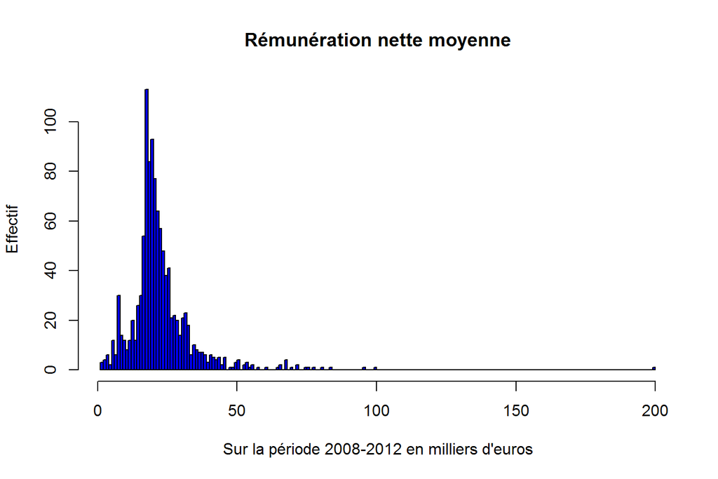

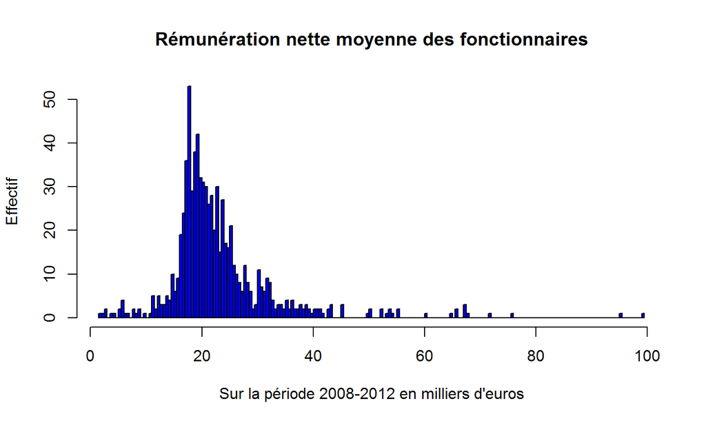

Lien vers la base de données synthétique Lien vers la base de données détaillée par année

## 4.2 Evolutions des rémunérations nettes sur la période 2008 - 2012

### 4.2.1 Ensemble des personnels fonctionnaires et non titulaires (hors élus)

**Salaire net moyen par tête (SMPT net) en EQTP, hors élus**

*Tableau 30*

| Année | Rém. nette totale (k€) | Variation (%) | SMPT net (€) | Variation (%) |
| --- | --- | --- | --- | --- |
| 2008 | 17 845 |  | 23 206 |  |
| 2009 | 18 098 |  | 23 473 |  |
| 2010 | 19 111 | 14 | 23 770 | 1,37 |
| 2011 | 19 931 |  | 24 129 |  |
| 2012 | 20 349 |  | 23 525 |  |

**Effet de noria sur salaires nets et taux de remplacements**

**Effet de noria** : *différence entre la rémunération annuelle des entrants à l’année N et des sortants à l’année N-1*.  
*Usuellement calculée sur les rémunérations brutes, ici sur les rémunérations nettes EQTP*  
*afin d’apprécier l’impact de cet effet sur l’évolution des rémunérations nette moyennes calculée au tableau précédent.*

*Tableau 31*

| Année | Noria EQTP (€) | En % de la MS N-1 | Remplacements EQTP | Taux de remplacements (%) |
| --- | --- | --- | --- | --- |
| 2009 | -3 450,4 | -0,641 | 33 | 4,7 |
| 2010 | 1 163,6 | 0,192 | 30 | 4,2 |
| 2011 | -1 557,7 | -0,252 | 31 | 4,2 |
| 2012 | -6 985,7 | -0,927 | 26 | 3,5 |

*MS N-1 : masse salariale nette de l’année n-1.*

**Distribution et variation sur la période du salaire moyen net par tête (SMPT net) en EQTP**

*Tableau 32*

| Statistique | Première année |
| --- | --- |
| Minimum | 1 642 |
| 1er quartile | 17 890 |
| Médiane | 20 610 |
| Moyenne | 23 210 |
| 3ème quartile | 25 190 |
| Maximum | 97 670 |

| Statistique | Dernière année |
| --- | --- |
| Minimum | 1 651 |
| 1er quartile | 18 280 |
| Médiane | 21 060 |
| Moyenne | 23 520 |
| 3ème quartile | 26 080 |
| Maximum | 142 500 |

*Nota :* La population retenue est constituée des agents qui :  
- ne font pas partie des 1 centiles extrêmaux  
- sont au moins présents 0 jours la première et la dernière année d’activité

**Comparaisons source INSEE/DGCL**

**Salaires annuels moyens 2011 et 2012 en EQTP (hors assistantes maternelles)**

*Tableau 33* ’

| Agrégat | Salaires nets 2011 (€) | Salaires nets 2012 (€) |
| --- | --- | --- |
| Ensemble | 21 876 | 22 176 |
| Titulaires | 22 632 | 22 920 |
| Autres salariés | 18 864 | NA |

*Champ : France. Salariés en équivalent-temps plein (EQTP) des collectivités territoriales (y compris bénéficiaires de contrats aidés, hors assistantes maternelles).*

**Distribution des salaires nets annuels en EQTP dans la fonction publique par versant en 2011**

*Tableau 34*

| Décile (k€) | FPE | FPT | FPH | Secteur privé |
| --- | --- | --- | --- | --- |
| D1 | 17 496 | 15 288 | 16 584 | 14 040 |
| D2 | 20 916 | 16 512 | 18 168 | 15 660 |
| D3 | 23 052 | 17 508 | 19 620 | 17 136 |
| D4 | 24 912 | 18 480 | 21 048 | 18 708 |
| D5 | 26 832 | 19 632 | 22 596 | 20 544 |
| D6 | 28 944 | 21 012 | 24 504 | 22 824 |
| D7 | 31 632 | 22 860 | 27 216 | 25 872 |
| D8 | 35 592 | 25 596 | 30 996 | 30 828 |
| D9 | 42 456 | 30 876 | 37 812 | 40 800 |

**Distribution des salaires nets annuels en EQTP dans la fonction publique territoriale par catégorie en 2011**

*Tableau 35*

[output not shown]

[Source INSEE, onglets Figure3, F1web et F3web](http://www.insee.fr/fr/ffc/ipweb/ip1486/ip1486.xls)

Lien vers la base de données

### 4.2.2 Fonctionnaires

**Titulaires et stagiaires**

**Salaire net moyen par tête (SMPT net) en EQTP**  
*Tableau 36*

| Année | Rém. nette totale (k€) | Variation (%) | SMPT net en EQTP (€) | Variation (%) |
| --- | --- | --- | --- | --- |
| 2008 | 14 575 |  | 22 703 |  |
| 2009 | 14 529 |  | 23 026 |  |
| 2010 | 15 267 | 9,45 | 23 524 | 5,19 |
| 2011 | 15 282 |  | 23 656 |  |
| 2012 | 15 953 |  | 23 882 |  |

**Effet de noria sur salaires nets et taux de remplacements**

*Tableau 37*

| Année | Noria EQTP (€) | En % de la MSN N-1 | Remplacements EQTP | Taux de remplacements (%) |
| --- | --- | --- | --- | --- |
| 2009 | -10 941 | -1,11 | 15 | 2,5 |
| 2010 | 6 524,5 | 0,87 | 19 | 3,2 |
| 2011 | -2 013,5 | -0,196 | 15 | 2,4 |
| 2012 | 477,89 | 0,039 | 12 | 2 |

*MS N-1 : masse salariale nette de l’année n-1.*

**Distribution et variation sur la période du salaire moyen net par tête (SMPT net) en EQTP**

*Tableau 38*

| Statistique | Première année |
| --- | --- |
| Minimum | 1 685 |
| 1er quartile | 17 970 |
| Médiane | 20 410 |
| Moyenne | 22 700 |
| 3ème quartile | 24 580 |
| Maximum | 97 670 |

| Statistique | Dernière année |
| --- | --- |
| Minimum | 2 672 |
| 1er quartile | 18 700 |
| Médiane | 21 480 |
| Moyenne | 23 880 |
| 3ème quartile | 25 760 |
| Maximum | 142 500 |

**Evolution du SMPT net des titulaires titulaires à temps complet**

*Tableau 39*

| Année | Rémunération nette totale (k€) | Variation (%) | SMPT (€) | Variation (%) |
| --- | --- | --- | --- | --- |
| 2008 | 10 579 |  | 23 150 |  |
| 2009 | 11 616 |  | 24 251 |  |
| 2010 | 11 500 | 12,7 | 24 468 | 7,7 |
| 2011 | 11 421 |  | 24 667 |  |
| 2012 | 11 918 |  | 24 932 |  |

**Distribution et variation sur la période du salaire moyen net par tête (SMPT net) des titulaires à temps complet**

*Tableau 40*

| Statistique | Première année |
| --- | --- |
| Minimum | 15 260 |
| 1er quartile | 18 080 |
| Médiane | 20 460 |
| Moyenne | 23 150 |
| 3ème quartile | 24 610 |
| Maximum | 97 670 |

| Statistique | Dernière année |
| --- | --- |
| Minimum | 15 590 |
| 1er quartile | 19 140 |
| Médiane | 21 830 |
| Moyenne | 24 930 |
| 3ème quartile | 27 090 |
| Maximum | 76 170 |

Lien vers la base de données

## 4.3 Glissement viellesse-technicité (GVT)

### 4.3.1 Ensemble des personnels

*Cette section est consacrée à la rémunération moyenne des personnes en place (RMPP), définies comme présentes deux années consécutives avec la même quotité*  
*L’évolution de la RMPP permet d’étudier le glissement viellesse-technicité “positif”, à effectifs constants sur deux années*  
*Le GVT positif est dû aux mesures statutaires et individuelles, à l’avancement et aux changements d’activité*

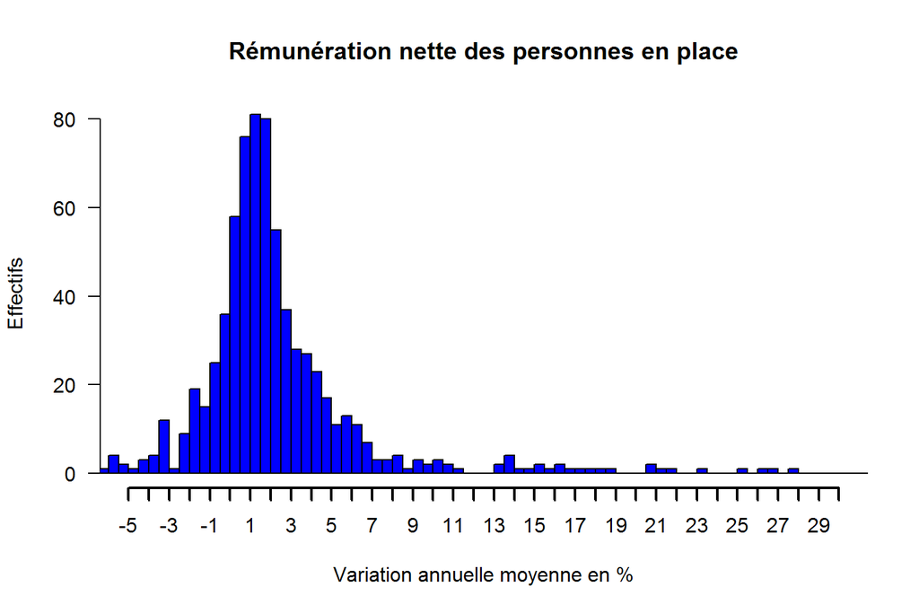

**Evolution de la RMPP nette en EQTP**

*Tableau 41*

| Année | Rémunération nette totale (k€) | Variation (%) | RMPP nette (k€) | Variation (%) |
| --- | --- | --- | --- | --- |
| 2009 | 15 443 |  | 24 670 |  |
| 2010 | 15 340 | 3,5 | 25 024 | 1,39 |
| 2011 | 15 591 |  | 24 867 |  |
| 2012 | 15 983 |  | 25 012 |  |

**Distribution et variation sur la période de la rémunération nette des personnes en place**

*Tableau 42*

| Statistique | Première année | Effectif |
| --- | --- | --- |
| Minimum | 3 885 |  |
| 1er quartile | 18 070 |  |
| Médiane | 20 780 |  |
| Moyenne | 23 410 | 690 |
| 3ème quartile | 24 940 |  |
| Maximum | 97 670 |  |

*Tableau 43*

| Statistique | Dernière année | Effectif |
| --- | --- | --- |
| Minimum | 1 651 |  |
| 1er quartile | 18 730 |  |
| Médiane | 21 620 |  |
| Moyenne | 24 470 | 745 |
| 3ème quartile | 26 320 |  |
| Maximum | 142 500 |  |

*Variation individuelle de rémunération nette en EQTP pour les personnels présents la première et la dernière année*

*Tableau 44*

[output not shown]

### 4.3.2 Titulaires et stagiaires

**Evolution de la RMPP nette en EQTP**

*Tableau 45*

| Année | Rémunération nette totale (k€) | Variation (%) | RMPP nette (k€) | Variation (%) |
| --- | --- | --- | --- | --- |
| 2009 | 13 071 |  | 23 722 |  |
| 2010 | 13 105 | 2,57 | 24 135 | 2,94 |
| 2011 | 13 242 |  | 24 209 |  |
| 2012 | 13 407 |  | 24 420 |  |

**Distribution et variation sur la période de la rémunération nette des fonctionnaires en place**

*Tableau 46*

| Statistique | Première année | Effectif |
| --- | --- | --- |
| Minimum | 5 638 |  |
| 1er quartile | 18 000 |  |
| Médiane | 20 390 |  |
| Moyenne | 22 630 | 619 |
| 3ème quartile | 24 310 |  |
| Maximum | 97 670 |  |

*Tableau 47*

| Statistique | Dernière année | Effectif |
| --- | --- | --- |
| Minimum | 1 685 |  |
| 1er quartile | 18 460 |  |
| Médiane | 21 240 |  |
| Moyenne | 23 580 | 767 |
| 3ème quartile | 25 720 |  |
| Maximum | 142 500 |  |

*Variation individuelle de rémunération nette en EQTP pour les personnels présents la première et la dernière année*

*Tableau 48*

[output not shown]

Lien vers la base de données

**Nota**  
*Personnes en place :* en fonction au moins deux années consécutives sur la période 2008 à 2012  
*Variation sur la période d’activité :* entre l’arrivée et le départ de la personne  
*Variation normalisée :* conforme à la définition INSEE (présente en début et en fin de période avec la même quotité)

Lien vers la base de données

### 4.4 Comparaisons avec la situation nationale des rémunérations

**Évolution en euros courants du SMPT et de la RMPP dans la FPT (en % et euros courants)**

*Tableau 49*

| Année | 2008-2009 | 2009-2010 | 2010-2011 | 2011-1012 | 2008-2012 | Moy. 2008-2012 | Médiane 2007-2011 |
| --- | --- | --- | --- | --- | --- | --- | --- |
| SMPT brut | 2,5 | 1,3 | 1,5 | 1,7 | 7,2 | 1,8 |  |
| SMPT net | 3,0 | 1,4 | 1,3 | 1,4 | 7,3 | 1,8 | 13,4 |
| RMPP brute | 3,3 | 2,5 | 2,5 | 2,7 | 11,5 | 2,8 |  |
| RMPP nette | 3,3 | 2,5 | 2,3 | 2,4 | 10,9 | 2,6 |  |

*Source : fichier général de l’État (FGE), DADS, SIASP, Insee, Drees. Traitement Insee, Drees, DGCL*  
Hors assistants maternels et familiaux, y compris bénéficiaires de contrats aidés.  
SMPT : Salaire moyen par tête en EQTP.  
RMPP : Agents présents 24 mois consécutifs chez le même employeur avec la même quotité de travail.  
Moyenne des variation géométriques annuelles pour les agents du champ.  
La dernière colonne présente la médiane des augmentations du SMPT net pour les agents présents en 2007 et 2011.

**Salaires nets annuels et évolution moyenne type de collectivité en € courants EQTP**

*Tableau 50*

| Type de collectivité | SMPT net 2011 (€) | SMPT net 2012 (€) | Évolution annuelle moy. 2007-2011 (%) |
| --- | --- | --- | --- |
| Communes | 21 575 | 21 120 | 2,5 |
| CCAS et caisses des écoles | 20 326 | 19 716 | 2,4 |
| EPCI à fiscalité propre | 24 088 | 23 088 | 3,1 |
| Autres structures intercommunales | 22 686 | 21 684 | 3,0 |
| Départements | 26 910 | 24 744 | 3,9 |
| SDIS | 30 548 | 29 940 | 3,4 |
| Régions | 24 137 | 22 836 | 3,8 |
| Autres collectivités locales | 26 242 | 24 696 | 3,2 |
| Ensemble (moyenne) | 22 954 | 22 176 | 2,9 |
| Ensemble (médiane) | 19 626 | NA |  |

*Champ : France. Salariés en équivalent-temps plein (EQTP) des collectivités territoriales (y compris bénéficiaires de contrats aidés, hors assistantes maternelles).*  
Conversion en euros courants, calcul CRC.  
[Source INSEE](http://www.insee.fr/fr/ffc/ipweb/ip1486/ip1486.xls)  
[Source DGAFP](http://infos.emploipublic.fr/dossiers/la-fonction-publique-en-chiffres/la-fonction-publique-en-chiffre-2013/non-defini-08/apm-71444/)

# 5. Tests réglementaires

## 5.1 Contrôle des heures supplémentaires, des NBI et primes informatiques

Il existe 1 non titulaires percevant une NBI.

Primes informatiques potentielles : aucune

*Tableau 51*

| Nombre de lignes NBI pour non titulaires | Nombre de bénéficiaires de PFI |
| --- | --- |
| 12 | 0 |

Lien vers la base de données NBI aux non titulaires  
Lien vers la base de données Primes informatiques

**Nota :**  
NBI: nouvelle bonification indiciaire  
PFI: prime de fonctions informatiques

## 5.2 Contrôle des vacations pour les fonctionnaires

Il y a 0 fonctionnaire(s) effectuant des vacations pour son propre établissement. Les bulletins concernés sont donnés en lien.

Lien vers les matricules des fonctionnaires concernés Lien vers les bulletins de paye correspondants

## 5.3 Contrôles sur les cumuls traitement indiciaire, indemnités et vacations des contractuels

**Contractuels effectuant des vacations (CEV)**

| Nombre de CEV | Nombre de lignes | Nombre de lignes indemnitaires | Nombre de lignes de traitement |
| --- | --- | --- | --- |
| 1 | 21 | 0 | 1 |

Lien vers le bulletins des CEV  
Lien vers la base de données Matricules des CEV  
Lien vers la base de données Cumul régime indemnitaire et vacations de CEV  
Lien vers la base de données Lignes de traitement indiciaire pour CEV

## 5.4 Contrôle sur les indemnités IAT et IFTS

*Tableau 52*

| Codes IFTS | Nombre de personnels percevant IAT et IFTS |
| --- | --- |
| 502N 502A 202N 202R 202A 502R 502V | 47 |

Codes IFTS retenus Lien vers la base de données

### Contrôle sur les IFTS pour catégories B et contractuels

*Tableau 53*

| Nombre de lignes de paye de contractuels percevant des IFTS | Nombre de lignes IFTS pour IB < 380 |
| --- | --- |
| 2 448 | 318 |

Lien vers la base de données Lignes IFTS pour contractuels Lien vers la base de données Lignes IFTS pour IB < 380

**Nota :** IB < 380 : fonctionnaire percevant un indice brut inférieur à 380

## 5.5 Contrôle sur les heures supplémentaires

*Tableau 54*

| Nombre de lignes HS en excès | Nombre de lignes IHTS anormales |
| --- | --- |
| 2 756 | NA |

Lien vers la base de données Heures suplémentaires en excès : matricules Lien vers la base de données IHTS anormales

**Nota :** HS en excès : au-delà de 25 heures par mois IHTS anormales : non attribuées à des fonctionnaires de catégorie B ou C.

## 5.6 Contrôle sur les indemnités des élus

| Matricule | Nom | Année | Emploi | Indemnités | Autres | Total |
| --- | --- | --- | --- | --- | --- | --- |
| 1002 P | AMPHOUX | 2008 | CONSEILLER COMMUNAUTAIRE | 2301,44 | 0 | 2301,44 |
| 1002 P | AMPHOUX | 2009 | CONSEILLER COMMUNAUTAIRE | 2710,56 | 0 | 2710,56 |
| 1002 P | AMPHOUX | 2010 | CONSEILLER COMMUNAUTAIRE | 2730,24 | 0 | 2730,24 |
| 1002 P | AMPHOUX | 2011 | CONSEILLER COMMUNAUTAIRE | 2737,08 | 0 | 2737,08 |
| 1002 P | AMPHOUX | 2012 | CONSEILLER COMMUNAUTAIRE | 2737,08 | 0 | 2737,08 |
| 108 T | BAFFERT | 2008 | CONSEILLER COMMUNAUT DELEGUE | 10175,88 | 0 | 10175,88 |
| 108 T | BAFFERT | 2009 | CONSEILLER COMMUNAUT DELEGUE | 11294,07 | 0 | 11294,07 |
| 108 T | BAFFERT | 2010 | CONSEILLER COMMUNAUT DELEGUE | 16841,07 | 0 | 16841,07 |
| 108 T | BAFFERT | 2011 | 12EME VICE PRESIDENT | 18703,20 | 0 | 18703,20 |
| 108 T | BAFFERT | 2012 | 12EME VICE PRESIDENT | 18703,20 | 0 | 18703,20 |
| 1163 P | QUEIROS | 2009 | CONSEILLER COMMUNAUT DELEGUE | 11294,07 | 0 | 11294,07 |
| 1163 P | QUEIROS | 2010 | CONSEILLER COMMUNAUT DELEGUE | 11376,06 | 0 | 11376,06 |
| 1163 P | QUEIROS | 2011 | CONSEILLER COMMUNAUT DELEGUE | 11404,44 | 0 | 11404,44 |
| 1163 P | QUEIROS | 2012 | CONSEILLER COMMUNAUT DELEGUE | 11404,44 | 0 | 11404,44 |
| 1212 T | HANFF | 2008 | CONSEILLER COMMUNAUT DELEGUE | 2684,97 | 0 | 2684,97 |
| 1223 E | MEUNIER RIVIERE | 2008 | CONSEILLER COMMUNAUTAIRE | 503,59 | 0 | 503,59 |
| 1319 J | SIMARD | 2008 | CONSEILLER COMMUNAUT DELEGUE | 7490,91 | 0 | 7490,91 |
| 1319 J | SIMARD | 2009 | CONSEILLER COMMUNAUT DELEGUE | 11294,07 | 0 | 11294,07 |
| 1319 J | SIMARD | 2010 | CONSEILLER COMMUNAUT DELEGUE | 11376,06 | 0 | 11376,06 |
| 1319 J | SIMARD | 2011 | CONSEILLER COMMUNAUT DELEGUE | 11404,44 | 0 | 11404,44 |
| 1319 J | SIMARD | 2012 | CONSEILLER COMMUNAUT DELEGUE | 11404,44 | 0 | 11404,44 |
| 1320 K | JOIRE | 2008 | CONSEILLER COMMUNAUTAIRE | 1797,85 | 0 | 1797,85 |
| 1320 K | JOIRE | 2009 | CONSEILLER COMMUNAUTAIRE | 2710,56 | 0 | 2710,56 |
| 1320 K | JOIRE | 2010 | CONSEILLER COMMUNAUTAIRE | 2730,24 | 0 | 2730,24 |
| 1320 K | JOIRE | 2011 | CONSEILLER COMMUNAUTAIRE | 2737,08 | 0 | 2737,08 |
| 1320 K | JOIRE | 2012 | CONSEILLER COMMUNAUTAIRE | 2737,08 | 0 | 2737,08 |
| 1321 L | JOLY | 2008 | CONSEILLER COMMUNAUTAIRE | 1797,85 | 0 | 1797,85 |
| 1321 L | JOLY | 2009 | CONSEILLER COMMUNAUTAIRE | 2710,56 | 0 | 2710,56 |
| 1322 M | LETEXIER | 2008 | CONSEILLER COMMUNAUTAIRE | 1797,85 | 0 | 1797,85 |
| 1322 M | LETEXIER | 2009 | CONSEILLER COMMUNAUTAIRE | 2710,56 | 0 | 2710,56 |

[output cut: 365 more lines]

Lien vers la base de données Rémunérations des élus

# Annexe

## Liens complémentaires

Lien vers la base de données des bulletins et lignes de paie Lien vers la base de données fusionnées des bulletins et lignes de paie

Lien vers le fichier des personnels

# Tableau des personnels : renseigner la catégorie

Utiliser les codes : A, B, C, ELU, AUTRES

En cas de changement de catégorie en cours de période, utiliser la catégorie AUTRES Cela peut conduire à modifier manuellement le fichier Catégories des personnels.csv

## Fiabilité du traitement statistique

### Eliminations des doublons

Retraitement de la base :

Elimination de 52 lignes dupliquées

Nombre de bulletins de paye de salaires (net ou brut) versés pour un champ Heures = 0 : 5057 Nombre de bulletins de paye de salaires (net ou brut) versés pour une quotité de travail indéfinie : 5057